# Kagle Data - Tidyverse

Coffy Andrews-Guo

2021-10-24

Source: [Kagle data - Data Analysis Jobs, Based on NYC Jobs - October 2021](https://www.kaggle.com/intelai/data-analysis-jobs?select=data_analysis_jobs.csv)

This dataset contains current job postings available on the City of New York’s official jobs site ( http://www.nyc.gov/html/careers/html/search/search.shtml ). Internal postings available to city employees and external postings available to the general public are included.

## Load Packages

```r
library("tidyverse")
library("reactable")
```

## Data Set

The `readr package` in tidyverse library contains the function `read_csv` that will import data from a csv file. The csv file was downloaded from Kaggle.com dataset on Data Analysis Jobs in NYC for October 2021. The imported data was read in to RStudio as a dataframe, `da`.

```r
da <- read_csv("https://github.com/candrewxs/Vignettes/blob/master/dadata/data_analysis_jobs.csv?raw=true")
```

Retrieve the names attribute of the da data set with the `names()` function.

```r
names(da)
```

```
#>  [1] "Job ID"                    "Agency"
#>  [3] "Posting Type"              "# Of Positions"
#>  [5] "Business Title"            "Civil Service Title"
#>  [7] "Title Code No"             "Level"
#>  [9] "Salary Range From"         "Salary Range To"
#> [11] "Salary Frequency"          "Work Location"
#> [13] "Division/Work Unit"        "Job Description"
#> [15] "Minimum Qual Requirements" "Preferred Skills"
#> [17] "Additional Information"    "To Apply"
#> [19] "Hours/Shift"               "Work Location 1"
#> [21] "Recruitment Contact"       "Residency Requirement"
#> [23] "Post Until"
```

## Group by Variables

### Dataset Question: How many job postings are Internal and External? What are the Levels and how many are available?

Create a new data frame using existing data frame (da) by extracting columns: Level and Posting Type. The `count()` combines `group_by` and `count rows in each group` into a single function. Renamed the column name “n” to “Count” and created an interactive data table.

```r
plot1 <- da %>%
   count(Level, `Posting Type`)  # dplyr package: group and count

colnames(plot1)[3] <- "Count"
# use function colnames() to rename column
# and access individual column names with colnames(df)[index]

reactable(plot1) # interactive data table
```

| Level | Posting Type | Count |
| --- | --- | --- |
| 0 | External | 101 |
| 0 | Internal | 136 |
| 1 | External | 81 |
| 1 | Internal | 94 |
| 2 | External | 68 |
| 2 | Internal | 89 |
| 3 | External | 36 |
| 3 | Internal | 45 |
| 4 | External | 12 |
| 4 | Internal | 18 |

[output cut: 17 more lines]

### Visualization

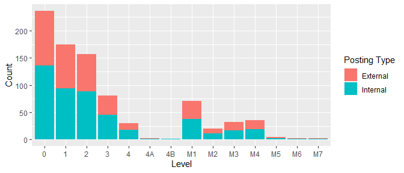

```r
# discrete visualization with ggplot2
p1 <- ggplot(data = plot1)
  p1 + geom_col(aes(Level, Count, fill = `Posting Type`))
```

### Dataset Question: What are the Business Titles categories which NYC hires Data Analysis to perform? Which Business Title has the highest demand for Data Analysis?

Create a new data frame using existing data frame (da) by extracting column: Business Title. Tidy data frame column to upper case and build a contingency table of the counts at each combination of factor levels with the `table()` function. Renamed the column name “pl2” to “Business Title” and created an interactive data table showing the frequency.

```r
plot2 <- as.data.frame(da[,5])

plot2$`Business Title` <- toupper(plot2$`Business Title`)

pl2 <- as.data.frame(table(plot2))

colnames(pl2)[1] <- "Business Title"

reactable(pl2)
```

| Business Title | Freq |
| --- | --- |
| .NET DEVELOPER | 6 |
| .NET DEVELOPER ANALYST | 2 |
| .NET PROGRAMMER/ANALYST (TECHNICAL LEAD) | 2 |
| .NET/CRM DEVELOPER | 2 |
| .NET/JAVASCRIPT DEVELOPER | 2 |
| 311 ASSISTANT BUSINESS SUPPORT ASSOCIATE | 1 |
| ADMINISTRATIVE HOUSING SUPERINTENDENT | 10 |
| ADVISOR, MAYOR'S OFFICE FOR ECONOMIC OPPORTUNITY | 2 |
| AGENCY IMPLEMENTATION AND SUPPORT PROGRAM EVALUATOR | 1 |
| ANALYSIS AND REPORTING ADMINISTRATOR | 2 |

[output cut: 368 more lines]

```r
summary(pl2) # calculates some statistics on the data
```

```
#>                                   Business Title      Freq
#>  .NET DEVELOPER                          :  1    Min.   : 1.000
#>  .NET DEVELOPER ANALYST                  :  1    1st Qu.: 2.000
#>  .NET PROGRAMMER/ANALYST (TECHNICAL LEAD):  1    Median : 2.000
#>  .NET/CRM DEVELOPER                      :  1    Mean   : 2.251
#>  .NET/JAVASCRIPT DEVELOPER               :  1    3rd Qu.: 2.000
#>  311 ASSISTANT BUSINESS SUPPORT ASSOCIATE:  1    Max.   :19.000
#>  (Other)                                 :372
```

Filter Business Titles with a frequency greater or equal to 10.

```r
pl_2 <- filter(pl2, Freq >= 10)

pl_2
```

```
#>                          Business Title Freq
#> 1 ADMINISTRATIVE HOUSING SUPERINTENDENT   10
#> 2                      BUSINESS ANALYST   19
#> 3        COMPUTER SPECIALIST (SOFTWARE)   16
#> 4                          DATA ANALYST   11
#> 5                       PROJECT MANAGER   14
```

### Visualization

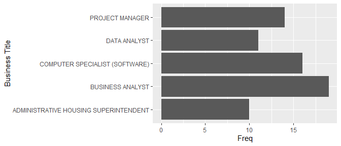

```r
p2 <- ggplot(pl_2)
  p2 + geom_col(aes(`Business Title`, Freq)) +
    coord_flip()
```

## Conclusion

Kagle data - Data Analysis Jobs, Based on NYC Jobs was loaded and analyzed using R base functions and packages from Tidyverse and Reactable. These are the Tidyverse packages that were utilized to load `(readr)` , perform data manipulation `(dplyr)` , create graphic representation of input data `(ggplot2)`.

Links [GitHub](https://rpubs.com/blesned/vignette)